# Chinese Foreign Direct Investment in Sub-Saharan Africa: Predicting Tiers of Investment

# Project Overview

Chinese has become one of the largest investors in Sub-Saharan Africa, particularly through the Belt and Road Initiative.

This project examines whether certain World Development Indicators (WDI) can predict the level of Chinese investment a country receives. Given a country's WDI profile, can we predict whether it receives negligible, low, moderate, or high Chinese investment?

```python
# Setup: libraries/packages, plot layout
import pandas as pd
import numpy as np
import matplotlib.pyplot as plt
import seaborn as sns

plt.style.use('fivethirtyeight')
font = {'size': 14}
plt.rc('font', **font)
plt.rcParams['mathtext.fontset'] = 'cm'
plt.rcParams['pdf.fonttype'] = 42
```

# Data Sources and ETL

My first dataset contains Chinese foreign direct investment (FDI) levels in all African countries, from 2004 to 2024. These totals include both state-owned enterprise and private firm investments. Included are levels of overall stock and annual flows, along with sector-specific totals. For now, I'll be focusing on the total annual FDI flows.

The focus of this project is Sub-Saharan Africa, so I'll be limiting my data to those countries (48 out of 54 countries).

The original dataset displays each country as a column, with FDI flow in a given year as rows/observations. To change the observation unit to country-year, I pivot the table below.

Source: https://www.sais-cari.org/chinese-investment-in-africa

Some notes on cleaning: The WDI classifies Djibouti as Middle East/North Africa, so I'll be removing it from the FDI dataset.

```python
# FDI Data

FDI_df = pd.read_excel('FDI_flow.xlsx', header=0)
FDI_melted = pd.melt(FDI_df, ['Year'], var_name='Country', value_name='FDI')

# limit sample to 2004-2024
FDI_melted = FDI_melted[FDI_melted['Year'] >= 2004].copy()

# remove Djibouti
FDI_melted = FDI_melted[FDI_melted["Country"] != "Djibouti"].copy()

print(f"FDI: {FDI_melted['Country'].nunique()} countries, {FDI_melted['Year'].min()}-{FDI_melted['Year'].max()}")
FDI_melted.head()
```

```
FDI: 48 countries, 2004-2024
```

|  | Year | Country | FDI |
| --- | --- | --- | --- |
| 1 | 2004 | Angola | 0.18 |
| 2 | 2005 | Angola | 0.47 |
| 3 | 2006 | Angola | 22.39 |
| 4 | 2007 | Angola | 41.19 |
| 5 | 2008 | Angola | -9.57 |

```python
# Display data types
FDI_melted.dtypes
```

|  | 0 |
| --- | --- |
| Year | int64 |
| Country | object |
| FDI | float64 |

**dtype:** object

```python
# Display missing values
FDI_melted.isnull().sum()
```

|  | 0 |
| --- | --- |
| Year | 0 |
| Country | 0 |
| FDI | 0 |

**dtype:** int64

# FDI Flow Concentration By Country and Region

Which countries and regions have had the highest annual FDI flows on average, over the entire period? Country-specific and/or regional characteristics can provide insight into China's investment strategies.

```python
# highest annual FDI flows on average, over the entire period (in millions, $)
highest_avg = FDI_melted.groupby('Country')['FDI'].mean().sort_values(ascending=False)
highest_avg.head(10)
```

| Country | FDI |
| --- | --- |
| South Africa | 462.626343 |
| Congo, Dem. Rep. | 277.523810 |
| Zambia | 211.269524 |
| Nigeria | 171.493095 |
| Kenya | 133.204762 |
| Niger | 121.926667 |
| Mauritius | 106.497143 |
| Zimbabwe | 98.035714 |
| Angola | 95.037619 |
| Ethiopia | 92.589048 |

**dtype:** float64

## Regional Patterns

Grouping by geography can be a step in analyzing whether China's strategy varies based regional characteristics (relative stability, resources, geopolitical/trade strategy)

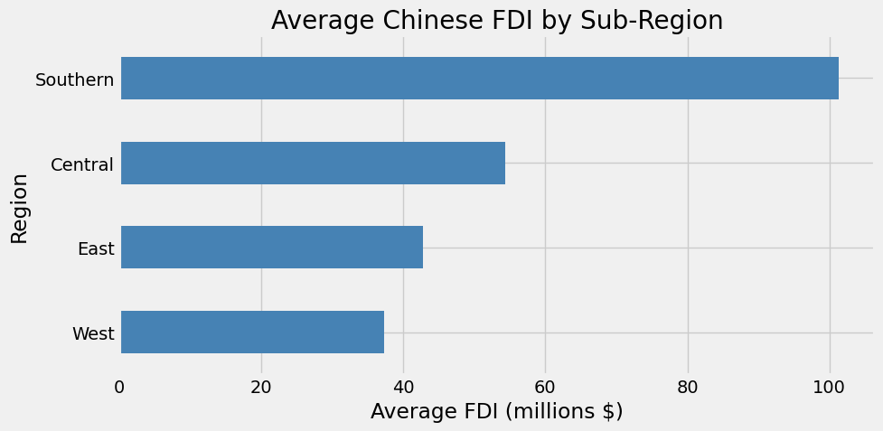

```python
# Define regions, map to countries
region_map = {
    **dict.fromkeys(['Burundi', 'Comoros', 'Eritrea', 'Ethiopia', 'Kenya',
                     'Madagascar', 'Malawi', 'Mauritius', 'Mozambique', 'Rwanda',
                     'Seychelles', 'Somalia', 'South Sudan', 'Tanzania', 'Uganda'], 'East'),
    **dict.fromkeys(['Benin', 'Burkina Faso', 'Cape Verde', 'The Gambia', 'Ghana', 'Guinea',
                     'Guinea-Bissau', 'Liberia', 'Mali', 'Niger', 'Nigeria', 'Senegal',
                     'Sierra Leone', 'Togo', "Cote d'Ivoire"], 'West'),
    **dict.fromkeys(['Cameroon', 'CAR', 'Chad',
                     'Congo, Dem. Rep.', 'Congo, Rep.', 'Equatorial Guinea',
                     'Gabon', 'Sao Tome & Principe'], 'Central'),
    **dict.fromkeys(['Angola', 'Botswana', 'Eswatini', 'Lesotho', 'Namibia',
                     'South Africa', 'Zambia', 'Zimbabwe', 'Mauritania'], 'Southern'),
}

FDI_melted['Region'] = FDI_melted['Country'].map(region_map)

fig, ax = plt.subplots(figsize=(10, 5))

FDI_melted.groupby('Region')['FDI'].mean().sort_values().plot(
    kind='barh', ax=ax, color='steelblue')
ax.set_xlabel('Average FDI (millions $)')
ax.set_title('Average Chinese FDI by Sub-Region')
plt.tight_layout()
plt.show()
```

# FDI Distribution

The figure below displays the total distribution of FDI amounts across the time period.

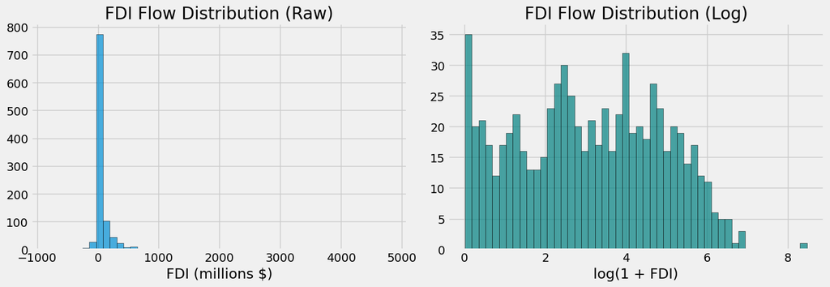

```
Zeros: 160 (15.9%), Negatives: 119 (11.8%)
Median: $6.9M, Mean: $54.2M
```

```python
# FDI distribution
fig, axes = plt.subplots(1, 2, figsize=(14, 5))

axes[0].hist(FDI_melted['FDI'], bins=50, edgecolor='black', alpha=0.7)
axes[0].set_title('FDI Flow Distribution (Raw)')
axes[0].set_xlabel('FDI (millions $)')

fdi_pos = FDI_melted[FDI_melted['FDI'] > 0]['FDI']
axes[1].hist(np.log1p(fdi_pos), bins=50, edgecolor='black', alpha=0.7, color='teal')
axes[1].set_title('FDI Flow Distribution (Log)')
axes[1].set_xlabel('log(1 + FDI)')

plt.tight_layout()
plt.show()

print(f"Zeros: {(FDI_melted['FDI']==0).sum()} ({(FDI_melted['FDI']==0).mean():.1%}), "
      f"Negatives: {(FDI_melted['FDI']<0).sum()} ({(FDI_melted['FDI']<0).mean():.1%})")
print(f"Median: ${FDI_melted['FDI'].median():.1f}M, Mean: ${FDI_melted['FDI'].mean():.1f}M")
```

The distribution is heavily right-skewed, suggesting that a small share of countries pull the distribution upward.

# Investment Tiers

Since the distribution is heavily skewed, defining "tiers" of investment may be more useful in identifying broad patterns of investment.

The tier thresholds below are roughly based on the distribution of raw FDI amounts across the entire sample (average being around $50M).

The figure below shows us the distribution of tiers by sub-region.

```python
# Create tier labels
def assign_tier(fdi):
    if fdi <= 1:
        return 'Negligible'
    elif fdi <= 50:
        return 'Low'
    elif fdi <= 200:
        return 'Moderate'
    else:
        return 'High'

FDI_melted['FDI_tier'] = FDI_melted['FDI'].apply(assign_tier)

print(" Tier Distribution ")
print(FDI_melted['FDI_tier'].value_counts())
print(f"\nAs percentages:")
print(FDI_melted['FDI_tier'].value_counts(normalize=True).map('{:.1%}'.format))
```

```
 Tier Distribution
FDI_tier
Low           373
Negligible    372
Moderate      174
High           89
Name: count, dtype: int64

As percentages:
FDI_tier
Low           37.0%
Negligible    36.9%
Moderate      17.3%
High           8.8%
Name: proportion, dtype: object
```

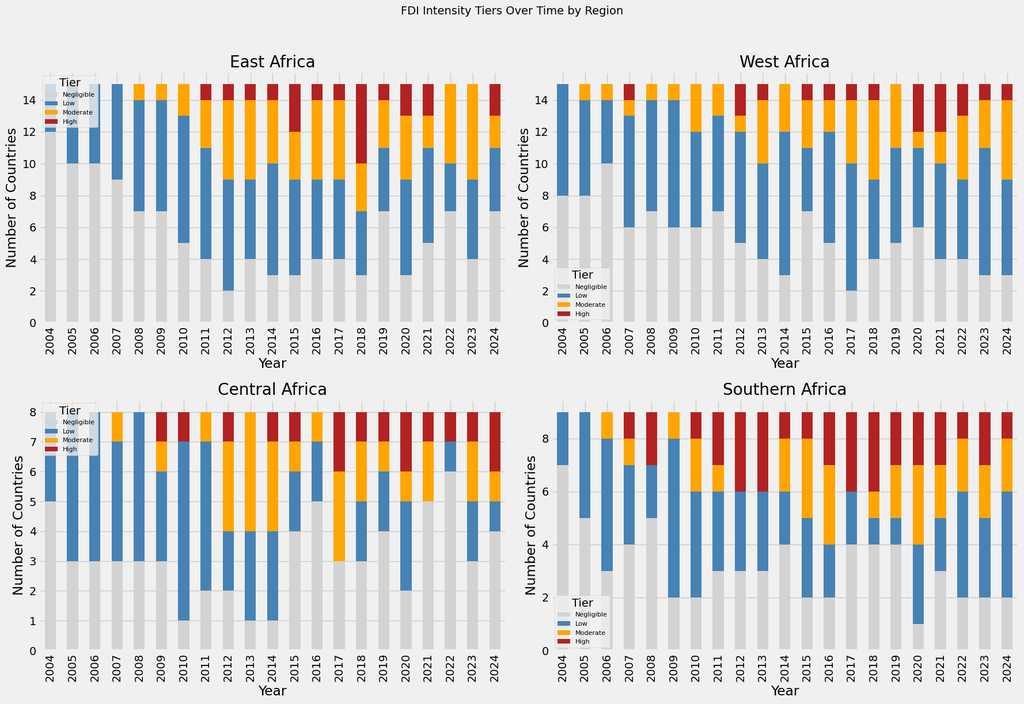

```python
# Visualize tier distribution over time, by region

fig, axes = plt.subplots(2, 2, figsize=(18, 12))
regions = ['East', 'West', 'Central', 'Southern']

for ax, region in zip(axes.flat, regions):
    region_data = FDI_melted[FDI_melted['Region'] == region]
    tier_by_year = region_data.groupby(['Year', 'FDI_tier']).size().unstack(fill_value=0)
    tier_order = [c for c in ['Negligible', 'Low', 'Moderate', 'High'] if c in tier_by_year.columns]
    tier_by_year[tier_order].plot(kind='bar', stacked=True, ax=ax,
                                  color=['lightgray', 'steelblue', 'orange', 'firebrick'])
    ax.set_title(f'{region} Africa')
    ax.set_xlabel('Year')
    ax.set_ylabel('Number of Countries')
    ax.legend(title='Tier', fontsize=8)

plt.suptitle('FDI Intensity Tiers Over Time by Region', fontsize=14, y=1.02)
plt.tight_layout()
plt.show()
```

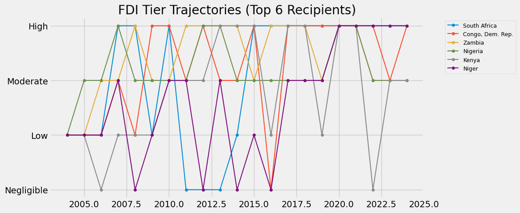

```python
# Movement between tiers for the countries with highest average flows
sample_countries = highest_avg.head(6).index.tolist()

tier_to_num = {'Negligible': 0, 'Low': 1, 'Moderate': 2, 'High': 3}
FDI_melted['tier_num'] = FDI_melted['FDI_tier'].map(tier_to_num)

fig, ax = plt.subplots(figsize=(12, 5))
for country in sample_countries:
    cdata = FDI_melted[FDI_melted['Country'] == country].sort_values('Year')
    ax.plot(cdata['Year'], cdata['tier_num'], marker='o', markersize=4, label=country, linewidth=1.5)

ax.set_yticks([0, 1, 2, 3])
ax.set_yticklabels(['Negligible', 'Low', 'Moderate', 'High'])
ax.set_title('FDI Tier Trajectories (Top 6 Recipients)')
ax.legend(bbox_to_anchor=(1.05, 1), loc='upper left', fontsize=9)
plt.tight_layout()
plt.show()
```

Across regions, investment levels are highest after about 2012-2013, likely due to the launch of the BRI.

For the top recipients, investment patterns peak and dip significantly until about 2016, and remain mostly high afterwards. This could be related to a combination of policy effect (3 years after the BRI), geopolitical shifts (changes in US foreign policy, etc.)

# World Development Indicators

My next dataset is from the World Development Indicator (WDI) database.

Generally speaking, institutional quality, private sector regulations, and infrastructure quality tend to be linked to investment from both state-led and private firms (Lu and Nugent, 2021; William, Agyapong and Abass, 2013).

To reduce the amount of noise in the modeling process, the dataset will be restricted to the following categories:

1. Economic/policy debt (GDP, national accounts, debt, etc.)
2. Environment (natural resource rents, emissions, etc.)
3. Infrastructure (railways, ICT, air transport)
4. Private sector (business environment/regulations, international trade, etc.)
5. Financial sector (banking access, mobile money, etc.)
6. Public sector (resource distribution, governance, etc.)

Sources:

https://databank.worldbank.org/source/world-development-indicators#

Cantah, William Godfred and Wiafe, Emmanuel Agyapong and Adams, Abass (2013): Foreign direct investment and trade policy openness in Sub-Saharan Africa.

Jeffrey B. Nugent, Jiaxuan Lu, China's outward foreign direct investment in the Belt and Road Initiative: What are the motives for Chinese firms to invest?, China Economic Review, Volume 68, 2021.

```python
# Standardize country names  (map WDI value to FDI value)
country_map = {
    'Cabo Verde': 'Cape Verde',
    'Gambia, The': 'The Gambia',
    'Somalia, Fed. Rep.': 'Somalia',
    'Central African Republic': 'CAR',
    'Sao Tome and Principe': 'Sao Tome & Principe',
}

# Replace ".." with NaN, standardize column names, remove metadata, pivot for merging
def clean_wdi(filepath):
    df = pd.read_excel(filepath, sheet_name=0)
    df = df.replace('..', np.nan)
    df = df.rename(columns={'Country Name': 'Country'})
    df['Country'] = df['Country'].replace(country_map)
    df = df[df['Country'].notna()].copy()
    df = df[~df['Country'].astype(str).str.contains('Data from database|Last Updated', na=False)].copy()
    year_cols = [c for c in df.columns if 'YR' in str(c)]
    long = pd.melt(df, id_vars=['Country', 'Series Name', 'Series Code'],
                   value_vars=year_cols, var_name='Year_raw', value_name='Value')
    long['Year'] = long['Year_raw'].astype(str).str.extract(r'(\d{4})').astype(int)
    long['Value'] = pd.to_numeric(long['Value'], errors='coerce')
    long = long.drop(columns=['Year_raw'])
    return long[long['Year'] <= 2024].copy()

# Load both WDI files
WDI_new = clean_wdi('WDI All variables.xlsx')              # 2012-2024
WDI_old = clean_wdi('WDI All variables 2004-2011.xlsx')    # 2004-2011

WDI_long = pd.concat([WDI_old, WDI_new], ignore_index=True)
WDI_long = WDI_long.drop_duplicates(
    subset=['Country', 'Series Code', 'Series Name', 'Year'], keep='last'
).copy()

print(f"WDI combined: {WDI_long['Series Name'].nunique()} indicators, "
      f"{WDI_long['Country'].nunique()} countries, "
      f"{WDI_long['Year'].min()}-{WDI_long['Year'].max()}")
```

[output not shown]

```python
series_metadata = pd.read_excel("WDI All variables.xlsx", sheet_name="Series - Metadata")

# Select relevant variables from metadata
selected_topics = [
    "Environment: Natural resources contribution to GDP",
    "Infrastructure: Communications",
    "Infrastructure: Technology",
    "Infrastructure: Transportation",
    "Private Sector & Trade: Business environment",
    "Public Sector: Policy & institutions",
    "Financial Sector: Access",
    "Financial Sector: Exchange rates & prices",
    "Economic Policy & Debt: National accounts: US$ at current prices: Aggregate indicators",
    "Economic Policy & Debt: National accounts: Growth rates"
]

selected_codes = (
    series_metadata.loc[series_metadata["Topic"].isin(selected_topics), "Code"]
    .dropna()
    .unique()
    .tolist()
)

# Add to WDI dataframe
WDI_long = WDI_long[WDI_long["Series Code"].isin(selected_codes)].copy()
```

```python
# Display data types
WDI_long.dtypes
```

[output not shown]

```python
# Display missing values
WDI_long.isnull().sum()
```

[output not shown]

```python
# Merge WDI with FDI
FDI_WDI = pd.merge(WDI_long, FDI_melted[['Country', 'Year', 'FDI']], on=['Country', 'Year'], how='inner')
print(f"Merged: {FDI_WDI.shape[0]} rows, {FDI_WDI['Country'].nunique()} countries, "
      f"{FDI_WDI['Year'].min()}-{FDI_WDI['Year'].max()}")
```

[output not shown]

# Model Outline

Based on the visualizations above, we can see that there is a regional pattern to FDI distribution, although there are regional outliers within the top 10.

To determine which characteristics predict investiment, below are 2 classification models (logistic regression and decision tree) using investment tier as the outcome variable (high, low, average, or negligible) and the above-listed WDI variable series as features (all variables in each series).

# Modeling: Feature Preparation

```python
# Pivot WDI data so that each observation country-year row includes all WDI data for that year
WDI_wide = WDI_long.pivot_table(index=['Country', 'Year'], columns='Series Name',
                                values='Value', aggfunc='first').reset_index()
wdi_cols = [c for c in WDI_wide.columns if c not in ['Country', 'Year']]

missing_pct = WDI_wide[wdi_cols].isnull().mean()

# Drop any indicators with more than 30% of data missing
missing_threshold = 0.30
usable = missing_pct[missing_pct < missing_threshold].index.tolist()
print(f"Keeping {len(usable)} / {len(wdi_cols)} indicators (<{missing_threshold:.0%} missing)")

# Merge with FDI and create analysis dataset
analysis_df = pd.merge(WDI_wide[['Country', 'Year'] + usable],
                       FDI_melted[['Country', 'Year', 'FDI', 'FDI_tier']],
                       on=['Country', 'Year'], how='inner')

# Forward fill with previous year values, and fill any remaining NaNs with median
analysis_df = analysis_df.sort_values(['Country', 'Year'])
analysis_df[usable] = analysis_df.groupby('Country')[usable].ffill()
for col in usable:
    analysis_df[col] = analysis_df[col].fillna(analysis_df[col].median())

print(f"Analysis data: {analysis_df.shape[0]} rows, {len(usable)} features")
print(f"Remaining NaN: {analysis_df[usable].isnull().sum().sum()}")
```

[output not shown]

# Classification Models

```python
from sklearn.preprocessing import StandardScaler
from sklearn.linear_model import LogisticRegression
from sklearn.tree import DecisionTreeClassifier, plot_tree
from sklearn.dummy import DummyClassifier
from sklearn.model_selection import GroupShuffleSplit, GroupKFold, cross_validate, cross_val_score
from sklearn.pipeline import Pipeline
from sklearn.metrics import accuracy_score, ConfusionMatrixDisplay, classification_report

X = analysis_df[usable].replace([np.inf, -np.inf], np.nan).fillna(0)
y = analysis_df['FDI_tier']
groups = analysis_df['Country']

# Split data 70/30, by country
gss = GroupShuffleSplit(n_splits=1, test_size=0.3, random_state=42)
train_idx, test_idx = next(gss.split(X, y, groups))

X_train, X_test = X.iloc[train_idx], X.iloc[test_idx]
y_train, y_test = y.iloc[train_idx], y.iloc[test_idx]

# Standardize
scaler = StandardScaler()
scaler.fit(X_train)
X_train_sc = scaler.transform(X_train)
X_test_sc = scaler.transform(X_test)

print(f"Train: {len(X_train)} from {len(set(groups.iloc[train_idx]))} countries")
print(f"Test: {len(X_test)} from {len(set(groups.iloc[test_idx]))} countries")
print(f"\nTraining class balance:")
print(y_train.value_counts())
```

[output not shown]

## Logistic Regression

```python
lr = LogisticRegression(max_iter=10000, class_weight='balanced',
                        random_state=42, multi_class='multinomial')
lr.fit(X_train_sc, y_train)
y_pred_lr = lr.predict(X_test_sc)

print(f"Accuracy: {accuracy_score(y_test, y_pred_lr):.3f}")
print()
print(classification_report(y_test, y_pred_lr, zero_division=0))
```

[output not shown]

```python
fig, ax = plt.subplots(figsize=(7, 6))
ConfusionMatrixDisplay.from_estimator(lr, X_test_sc, y_test,
    labels=['Negligible', 'Low', 'Moderate', 'High'],
    cmap=plt.cm.Blues, normalize='true', ax=ax)
ax.set_title('Logistic Regression')
plt.tight_layout()
plt.show()
```

[output not shown]

```python
# Top features
tier_labels = lr.classes_.tolist()
short_names = [c.replace('_lag1', '')[:40] for c in usable]

if 'High' in tier_labels:
    high_idx = tier_labels.index('High')
    high_coefs = pd.DataFrame({
        'Feature': short_names,
        'Coef': lr.coef_[high_idx]
    }).sort_values('Coef', key=abs, ascending=False).head(15)

    fig, ax = plt.subplots(figsize=(10, 6))
    colors = ['coral' if v < 0 else 'steelblue' for v in high_coefs['Coef']]
    ax.barh(range(len(high_coefs)), high_coefs['Coef'].values, color=colors)
    ax.set_yticks(range(len(high_coefs)))
    ax.set_yticklabels(high_coefs['Feature'].values, fontsize=9)
    ax.set_xlabel('Coefficient')
    ax.set_title('Top 15 Predictors of High FDI')
    ax.axvline(x=0, color='black', linewidth=0.5)
    plt.tight_layout()
    plt.show()
```

[output not shown]

## Decision Tree

```python
dt = DecisionTreeClassifier(max_depth=4, random_state=42, class_weight='balanced')
dt.fit(X_train_sc, y_train)
y_pred_dt = dt.predict(X_test_sc)

print(f"Accuracy: {accuracy_score(y_test, y_pred_dt):.3f}")
print()
print(classification_report(y_test, y_pred_dt, zero_division=0))
```

[output not shown]

```python
fig, ax = plt.subplots(figsize=(7, 6))
ConfusionMatrixDisplay.from_estimator(dt, X_test_sc, y_test,
    labels=['Negligible', 'Low', 'Moderate', 'High'],
    cmap=plt.cm.Blues, normalize='true', ax=ax)
ax.set_title('Decision Tree')
plt.tight_layout()
plt.show()
```

[output not shown]

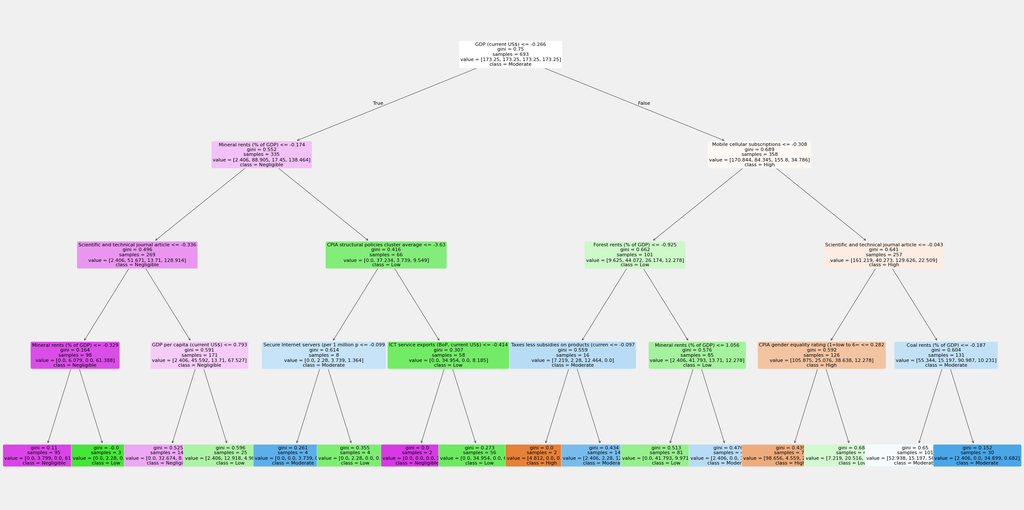

```python
# Visualize the tree
fig, ax = plt.subplots(figsize=(24, 12))
plot_tree(dt, feature_names=short_names,
          class_names=['High', 'Low', 'Moderate', 'Negligible'],
          filled=True, ax=ax, fontsize=8, rounded=True)
plt.tight_layout()
plt.show()
```

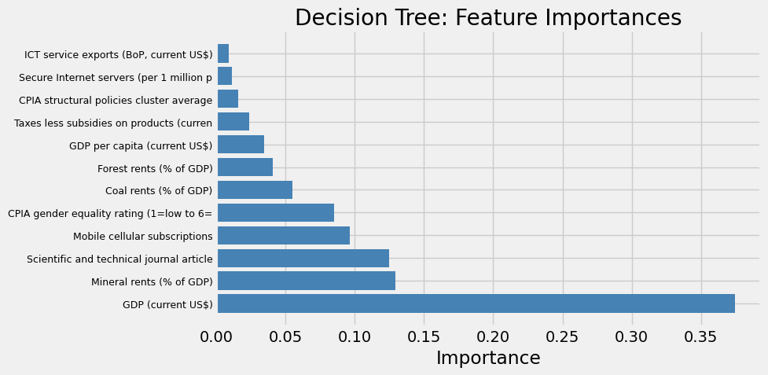

```python
# Feature importance
imp = pd.DataFrame({'Feature': short_names, 'Importance': dt.feature_importances_})
imp = imp[imp['Importance'] > 0].sort_values('Importance', ascending=False)

fig, ax = plt.subplots(figsize=(10, 5))
ax.barh(range(len(imp)), imp['Importance'].values, color='steelblue')
ax.set_yticks(range(len(imp)))
ax.set_yticklabels(imp['Feature'].values, fontsize=9)
ax.set_xlabel('Importance')
ax.set_title('Decision Tree: Feature Importances')
plt.tight_layout()
plt.show()
```

## Cross-Validation and Baselines

```python
groups_all = analysis_df['Country']
gkf = GroupKFold(n_splits=5)

models = {
    'Majority Class': Pipeline([('scaler', StandardScaler()),
                                ('model', DummyClassifier(strategy='most_frequent'))]),
    'Stratified Random': Pipeline([('scaler', StandardScaler()),
                                   ('model', DummyClassifier(strategy='stratified', random_state=42))]),
    'Logistic Regression': Pipeline([('scaler', StandardScaler()),
                                     ('model', LogisticRegression(max_iter=10000, class_weight='balanced'))]),
    'Decision Tree': Pipeline([('scaler', StandardScaler()),
                               ('model', DecisionTreeClassifier(max_depth=4, class_weight='balanced',
                                                                random_state=42))]),
}

cv_results = []
for name, pipe in models.items():
    scores = cross_val_score(pipe, X, y, cv=gkf, groups=groups_all, scoring='accuracy')
    cv_results.append({'Model': name, 'Mean Accuracy': scores.mean(), 'Std': scores.std()})

cv_df = pd.DataFrame(cv_results).sort_values('Mean Accuracy', ascending=False)
print(cv_df.to_string(index=False))
```

```
              Model  Mean Accuracy      Std
      Decision Tree       0.429312 0.020116
Logistic Regression       0.397778 0.063619
     Majority Class       0.327725 0.064844
  Stratified Random       0.301270 0.032033
```

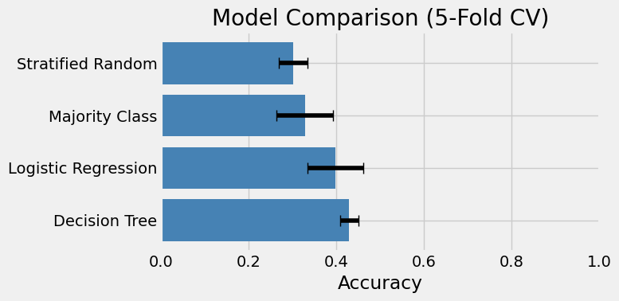

```python
fig, ax = plt.subplots(figsize=(8, 4))
ax.barh(cv_df['Model'], cv_df['Mean Accuracy'],
        xerr=cv_df['Std'], color='steelblue', capsize=5)
ax.set_xlabel('Accuracy')
ax.set_title('Model Comparison (5-Fold CV)')
ax.set_xlim(0, 1)
plt.tight_layout()
plt.show()
```

## Summary

Overall, the decision tree model seemed to perform best, which makes sense given the volume of correlated features. Features related to overall economic strength (GDP), features connected to telecommunication infrastructure, along with features linked to resource endowments, seem to dominate predictions.

```python
from google.colab import drive
drive.mount('/content/drive')
```

```python
%shell jupyter nbconvert --to html '/content/drive/MyDrive/Colab Notebooks/FDIFinal.ipynb' --output index
```

[output not shown]

[output cut: 136 more lines]

[output not shown]

[output not shown]